# Excersice Sheet 7

A broker wants to use linear regression to find out which factors have a large influence on the price of a property. For this purpose, the variables described in Table 1 are given for the last 88 sales in the broker’s region.

Table 1 House price record

| Variabel | Description |
| --- | --- |
| `price` | house price ($\times$ 1,000 EUR) |
| `bdrms` | number bedrooms |
| `lotsize` | parking area (m$^2$) |
| `sqrm` | house area (m$^2$) |
| `country` | $==1$ when in country house style |
| `lprice` | `log(price)` |
| `llotsize` | `log(lotsize)` |
| `lsqrm` | `log(sqrm)` |

1. Create a linear regression model with `price` as dependent variable and `bdrms`, `lotsize`, `sqrm` und `country` as independent variables.
   1. Determine the regression coefficients and $p$-values of the dependent variable and compare their influence within the model on the predicted value for `price`.
   2. Determine how much variance of the dependent variable is explained.
   3. Check the residuals (graphically) for normal distribution and homoskedasticity.

```r
# Solution for Task 1...
height<-read.csv("C:/Users/atray/OneDrive/Documents/R/hprice.csv")
lmprice<- lm(price~bdrms+lotsize+sqrm+country, data = height )
summary(lmprice)
```

```
##
## Call:
## lm(formula = price ~ bdrms + lotsize + sqrm + country, data = height)
##
## Residuals:
##      Min       1Q   Median       3Q      Max
## -122.268  -38.271   -6.545   28.210  218.040
##
## Coefficients:
##               Estimate Std. Error t value Pr(>|t|)
## (Intercept) -24.126528  29.603455  -0.815  0.41741
## bdrms        11.004292   9.515260   1.156  0.25080
## lotsize       0.022345   0.006918   3.230  0.00177 **
## sqrm          1.337325   0.143577   9.314 1.53e-14 ***
## country      13.715542  14.637265   0.937  0.35146
## ---
## Signif. codes:  0 '***' 0.001 '**' 0.01 '*' 0.05 '.' 0.1 ' ' 1
##
## Residual standard error: 59.88 on 83 degrees of freedom
## Multiple R-squared:  0.6758, Adjusted R-squared:  0.6602
## F-statistic: 43.25 on 4 and 83 DF,  p-value: < 2.2e-16
```

```r
anova(lmprice)
```

```
## Analysis of Variance Table
##
## Response: price
##           Df Sum Sq Mean Sq F value    Pr(>F)
## bdrms      1 236943  236943  66.088 3.592e-12 ***
## lotsize    1  72206   72206  20.140 2.298e-05 ***
## sqrm       1 307982  307982  85.902 1.896e-14 ***
## country    1   3148    3148   0.878    0.3515
## Residuals 83 297576    3585
## ---
## Signif. codes:  0 '***' 0.001 '**' 0.01 '*' 0.05 '.' 0.1 ' ' 1
```

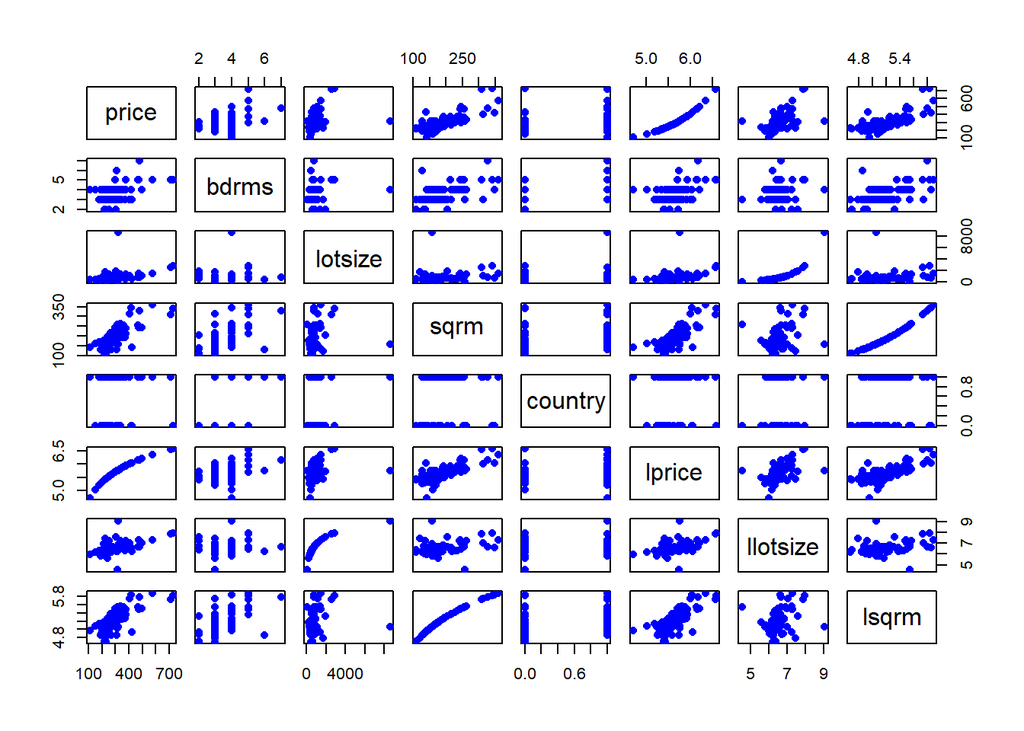

```r
plot(height, pch=16, col="blue")
abline(lmprice)
```

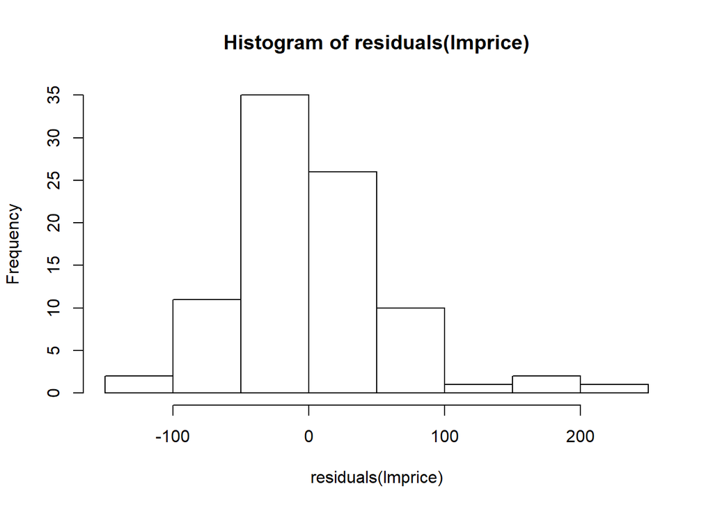

```r
hist(residuals(lmprice))
```

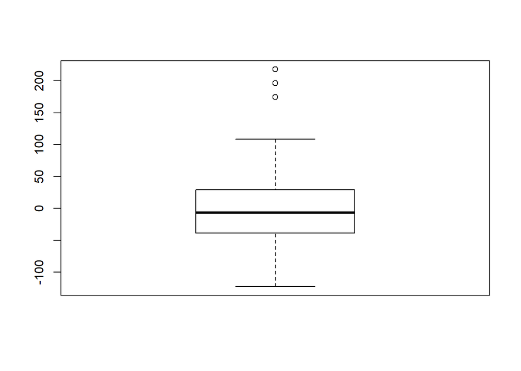

```r
boxplot(residuals(lmprice))
```

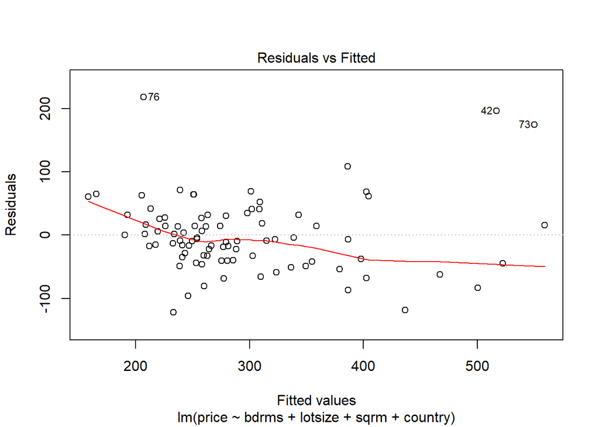

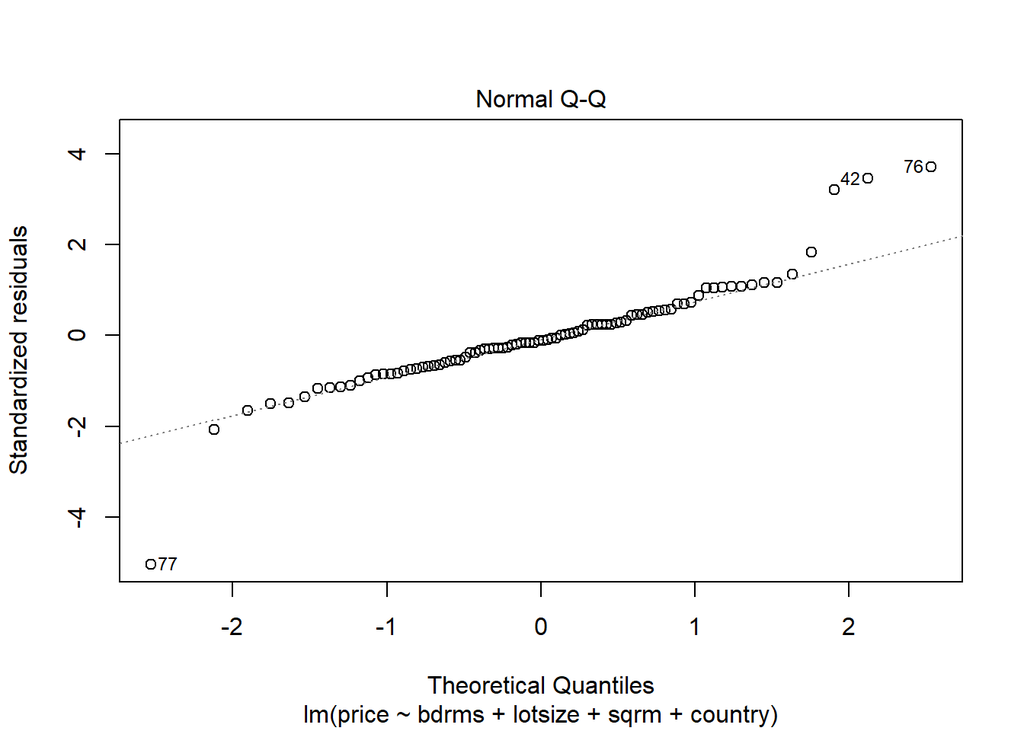

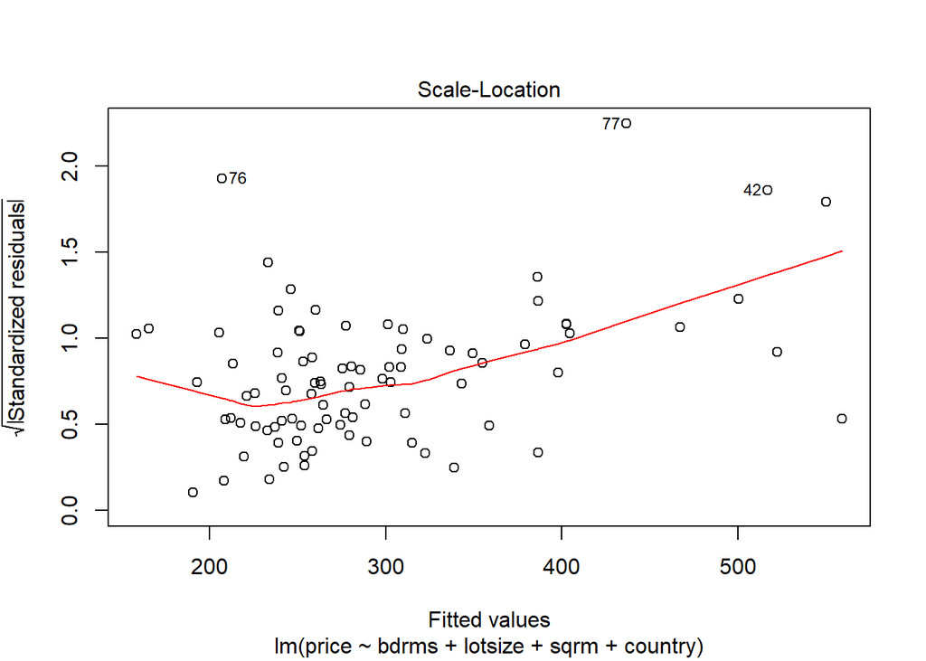

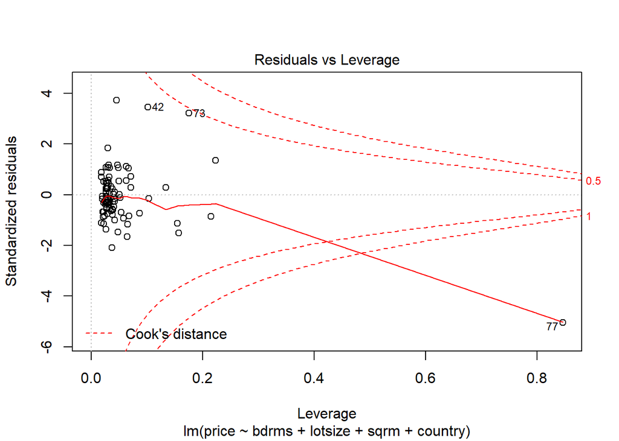

```r
#par(mfrow=c(2,2))
plot(lmprice)
```

2. Given be the linear regression model from task 1.
   1. Create a scatterplot to display the relationship between the predicted value for `price` and the residual size.
   2. For some houses, the price forecast of the broker model is more than EUR 100,000 off. Highlight houses with a residual size of more than 100 or less than 100. What could be the reasons for high model inaccuracies?
   3. Can the $R^2$-value be increased by using a linear transformation of one of the independent variables?

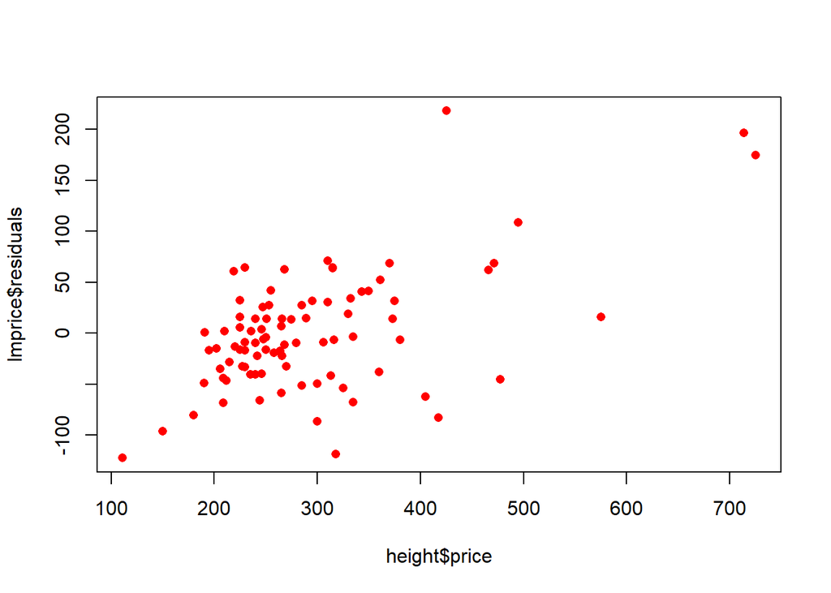

```r
# Solution for Task 2...
library(dplyr)
library(stringr)
plot(height$price,lmprice$residuals,pch=16, col="red")
```

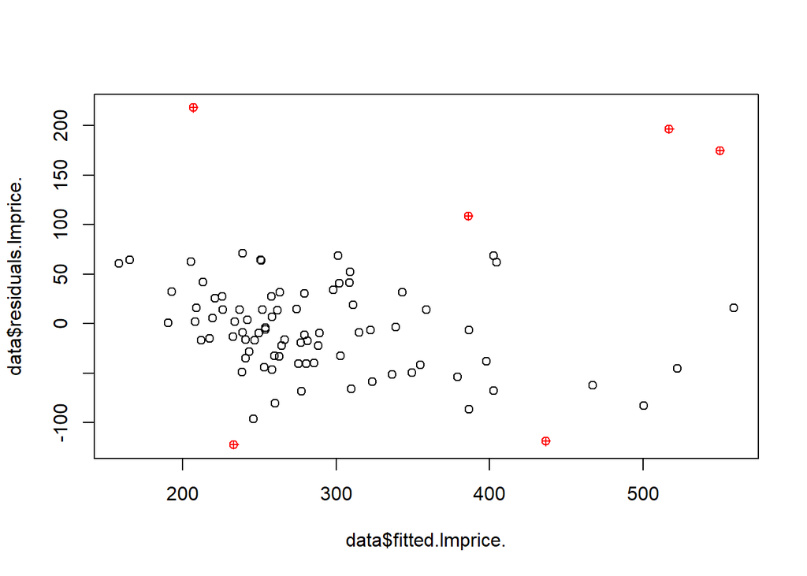

```
## integer(0)
```

```r
residuals<-data.frame(residuals(lmprice))
fitted <- data.frame(fitted(lmprice))
data <- data.frame(fitted, residuals)


outliers <- rbind(filter(data, data$residuals.lmprice. < -100), filter(data, data$residuals.lmprice. >100))
plot(x=data$fitted.lmprice., y=data$residuals.lmprice.) +
points(x=outliers$fitted.lmprice, y=outliers$residuals.lmprice, col = "red", pch=10)
```

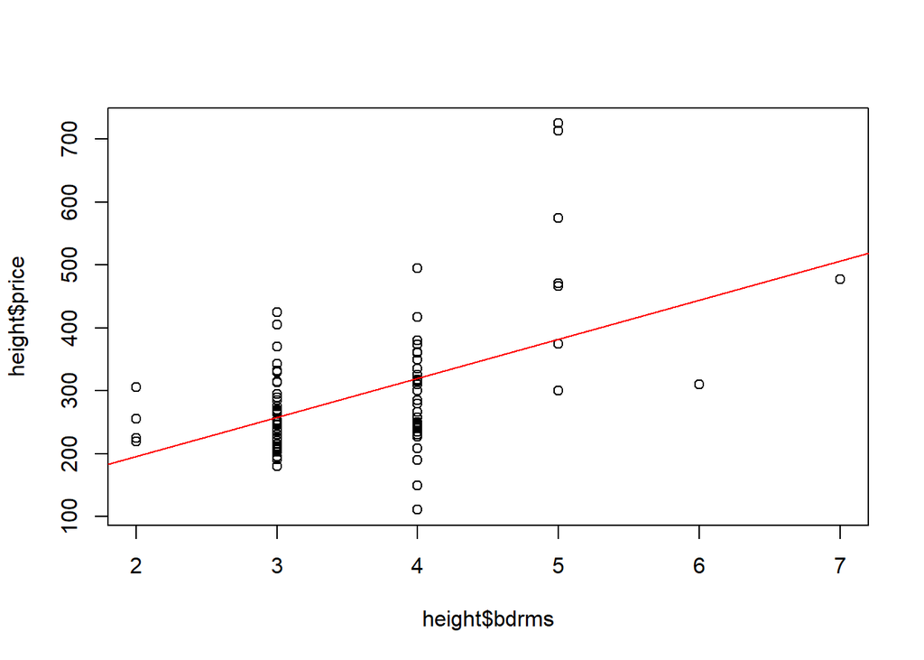

```
## integer(0)
```

```r
height$sqrtbed <- log(height$bdrms)

pricebed <- lm(price ~ bdrms, height)
plot(x=height$bdrms, y=height$price)+
abline(pricebed, col='red')
```

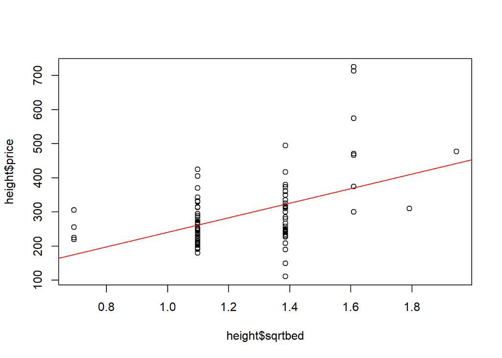

```
## integer(0)
```

```r
pricesqrtbed <- lm(price ~ sqrtbed, height)
plot(x=height$sqrtbed, y=height$price)+
abline(pricesqrtbed, col='red')
```

```r
coefficients(pricebed)
```

```
## (Intercept)       bdrms
##    72.23111    62.02456
```

```r
coefficients(lmprice)
```

```
##  (Intercept)        bdrms      lotsize         sqrm      country
## -24.12652827  11.00429220   0.02234481   1.33732481  13.71554214
```

```r
coefficients(pricesqrtbed)
```

```
## (Intercept)     sqrtbed
##    27.80621   213.23981
```

```r
summary(pricebed)
```

```
##
## Call:
## lm(formula = price ~ bdrms, data = height)
##
## Residuals:
##     Min      1Q  Median      3Q     Max
## -209.33  -52.81   -7.83   32.20  342.65
##
## Coefficients:
##             Estimate Std. Error t value Pr(>|t|)
## (Intercept)    72.23      41.55   1.738   0.0857 .
## bdrms          62.02      11.34   5.470 4.34e-07 ***
## ---
## Signif. codes:  0 '***' 0.001 '**' 0.01 '*' 0.05 '.' 0.1 ' ' 1
##
## Residual standard error: 88.98 on 86 degrees of freedom
## Multiple R-squared:  0.2581, Adjusted R-squared:  0.2495
## F-statistic: 29.93 on 1 and 86 DF,  p-value: 4.344e-07
```

```r
summary(lmprice)
```

```
##
## Call:
## lm(formula = price ~ bdrms + lotsize + sqrm + country, data = height)
##
## Residuals:
##      Min       1Q   Median       3Q      Max
## -122.268  -38.271   -6.545   28.210  218.040
##
## Coefficients:
##               Estimate Std. Error t value Pr(>|t|)
## (Intercept) -24.126528  29.603455  -0.815  0.41741
## bdrms        11.004292   9.515260   1.156  0.25080
## lotsize       0.022345   0.006918   3.230  0.00177 **
## sqrm          1.337325   0.143577   9.314 1.53e-14 ***
## country      13.715542  14.637265   0.937  0.35146
## ---
## Signif. codes:  0 '***' 0.001 '**' 0.01 '*' 0.05 '.' 0.1 ' ' 1
##
## Residual standard error: 59.88 on 83 degrees of freedom
## Multiple R-squared:  0.6758, Adjusted R-squared:  0.6602
## F-statistic: 43.25 on 4 and 83 DF,  p-value: < 2.2e-16
```

```r
summary(pricesqrtbed)
```

```
##
## Call:
## lm(formula = price ~ sqrtbed, data = height)
##
## Residuals:
##     Min      1Q  Median      3Q     Max
## -212.42  -56.41  -10.07   36.83  354.00
##
## Coefficients:
##             Estimate Std. Error t value Pr(>|t|)
## (Intercept)    27.81      54.40   0.511    0.611
## sqrtbed       213.24      42.95   4.965 3.44e-06 ***
## ---
## Signif. codes:  0 '***' 0.001 '**' 0.01 '*' 0.05 '.' 0.1 ' ' 1
##
## Residual standard error: 91.08 on 86 degrees of freedom
## Multiple R-squared:  0.2228, Adjusted R-squared:  0.2137
## F-statistic: 24.65 on 1 and 86 DF,  p-value: 3.445e-06
```

3. Graphically display the relationship between `bdrms` and `price`. Check whether this relationship is also reflected in the regression model from Task 1. Create a regression model with `bdrms` as the only independent variable. Compare the regression coefficients with those of the model from Task 1 and interpret the differences.

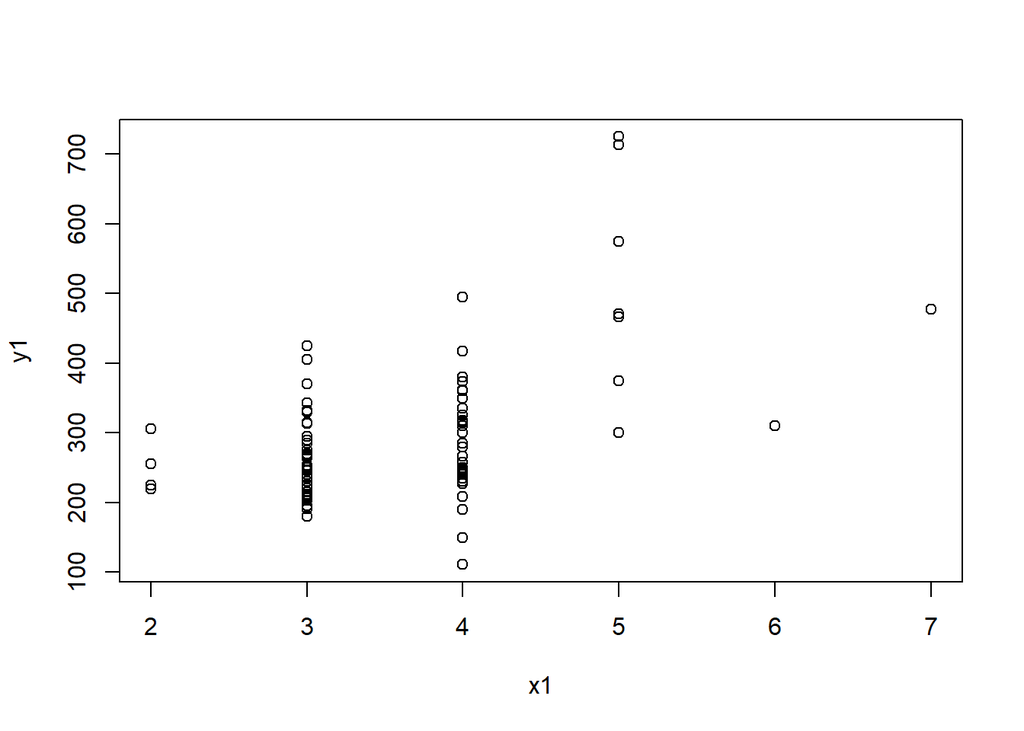

```r
# Solution for Task 3...
x1<- height$bdrms
y1<- height$price
plot(x1, y1)
```

```r
lmbdrms<-lm(price~bdrms, data = height)
summary(lmbdrms)
```

```
##
## Call:
## lm(formula = price ~ bdrms, data = height)
##
## Residuals:
##     Min      1Q  Median      3Q     Max
## -209.33  -52.81   -7.83   32.20  342.65
##
## Coefficients:
##             Estimate Std. Error t value Pr(>|t|)
## (Intercept)    72.23      41.55   1.738   0.0857 .
## bdrms          62.02      11.34   5.470 4.34e-07 ***
## ---
## Signif. codes:  0 '***' 0.001 '**' 0.01 '*' 0.05 '.' 0.1 ' ' 1
##
## Residual standard error: 88.98 on 86 degrees of freedom
## Multiple R-squared:  0.2581, Adjusted R-squared:  0.2495
## F-statistic: 29.93 on 1 and 86 DF,  p-value: 4.344e-07
```